# Report

Zak Vinter & Nick Power

10-29-2022

### Topic / Motivation

Our topic is studying the effects of implementing video assistant referees (VAR) in soccer. VAR is a new version of refereeing in which replays can be showed to the on-field referee, allowing them to make sure decisions are correct. This means penalties could be assigned when the on-field referee missed the foul committed during regular game play, or a penalty is ruled out after the on-field referee wrongly gives a penalty. We will look at the effects over multiple variables, however our main analysis is whether VAR has any effect on the number of penalties received. The theory behind this is that VAR enables the referees to not miss any foul during the game. Therefore, we would expect the number of penalties awarded to increase as all fouls committed are caught. Also, fouls tend to look a lot worse in slow motion so having replays my exaggerate the severity of fouls committed. Penalties awarded can of course be ruled out if the on-field referee makes a mistake, however this rarely happens as the mistake by the referee needs to be clear and obvious by the rule book. This means many tackles that are border line fouls, will not be ruled out.

The study we have designed is a difference-in-difference study. England was one of the first countries to adopt VAR, bringing it in for the 19/20 season. This allows us to compare England (the treatment) to Scotland (the control). Scotland still has not brought in VAR giving three full years of data to compare post treatment effects. The validity of this policy as an exogenous shock is not 100% clear. The English league does not appear to have been chosen randomly to the be first to implement this policy. However, the reasoning does not appear to be linked to the number of penalties. Referees all over the world make mistakes and all referees want this technology as an assistance. Mistakes made were not worse in England than other countries, creating faster action for this policy. The reasons that it was the first country to implement the policy is that the English league is the best league in the world with the most fans worldwide. Therefore, they were the trailblazers and one of the only leagues with the money to implement such technology so fast. Therefore we are not worried about there being validity concerns tied to the policy.

In terms of data, we have gathered this through web-scraping. We have data for years through 2013-2022, giving us 6 years pre-treatment and 3 post-treatment. We believe this is enough pre data to give us a good idea of past parallel trends. For each season we have penalty data per team. The English league has 20 teams in it per season and the Scottish league has 12. The variables we have scraped are penalties received, penalties scored, conversion rate, and missed penalties.Both country datasets have the same variables. This gives us sufficient data to use to compare the effects of the policy change.

### Data Processing

After scraping the data for all 9 nine years across both countries, we created a total column for every year. This counts the total number of penalties received for every team in the league for that season. After this we created to vectors. One including the 9 years (2013, 2014, etc.) and the other all the totals for each season. Then we created a data set out of these vectors which has 9 observations and 2 variables. We then added a average penalties per team variable. This is the number of penalties handed out in the whole league, divided by the number of teams. We do this because there are a different number of teams in each league. Therefore, this is a much more accurate way to compare penalties received between the two leagues. These data sets are called the Annual_Scotland and Annual_England. Next we created an appended data set for both countries. This consists of all the teams and over all the years. This is the tidy version of the data.

The next step was to take the two Annual data sets and combine them for a joined data set. Firstly we added a country variable to both the data sets. This allows us to distinguish between the observations across countries. After combining, this data set included average penalties per team for both countries over all years. The variables were (year, country, penalties received, and average penalties per team). This is a tidy version of this data set and will allow us to create visualizations. After this we conducted the same process for the two Appended data sets. We added the countries name and then used rbind to create a data set for all observations. This has all teams across all years for each country. The variables were (club, country, year,penalties received, penalties scored, penalties missed, conversion rate, and the total penalties received for all teams in that league that year). This is called the Appended_Joined. This process has left us with two main data sets. The tidy_joined and the Appended_Joined. The main variables we will use for analysis are ‘average penalties per team’, and ‘penalties received at club level’.

In terms of adjustment the main adjustment was the average penalties per team transformation described above. There was no other transformations needed for this data. Additionally there was no extreme values or NA’s to deal with in this data set. All of the data that was scraped has been used, it has just been wrangled, cleaned and transformed.

### Results/Visualizations

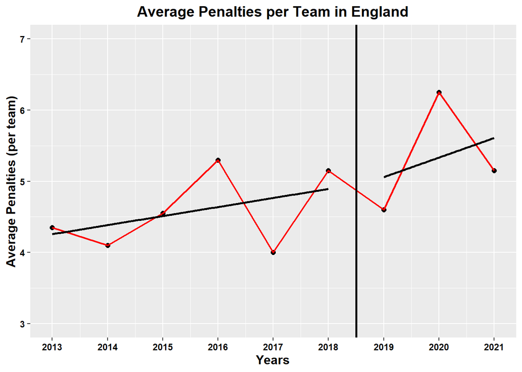

The first graphical depiction is of average penalties per team in England. There is a line of best fit to illustrate how the graph would look had it been drawn smoothed out. The line across the entirety of the graph as a vertical asymptote symbolizes the policy that went into effect regarding the instant replay for assigning penalties. The post line drawn further along the x-axis shows what appears to a be a marked increase in average penalties per team. Something that warrants further investigation. But promising nonetheless.

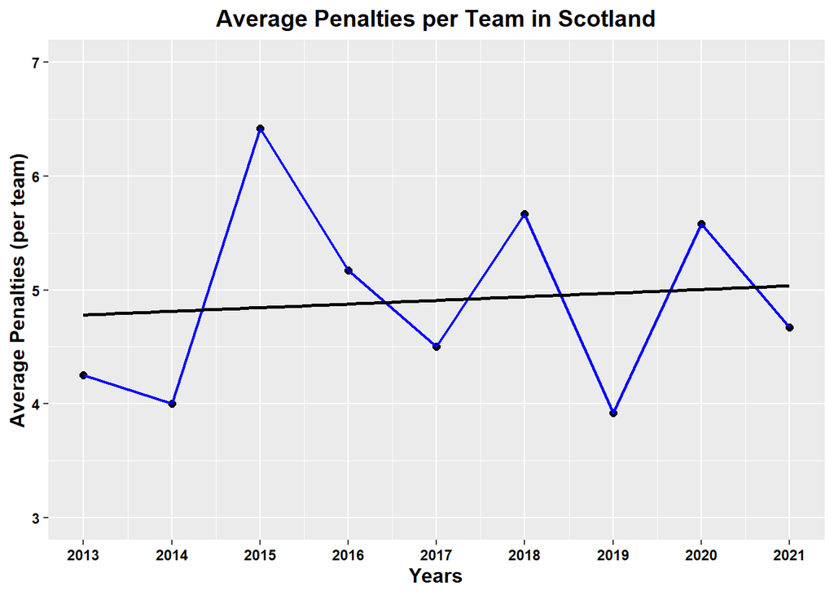

The second visual shows Scotland and the average penalties per team in Scotland. It is a nice juxtaposition to have Just below the English graph. Without the line of best fit it is hard to see that there is an ever so slight increase of penalties per team across the range of years in the data set. However it is quite gradual, which makes for a nice sort of control in our project hypothesis.

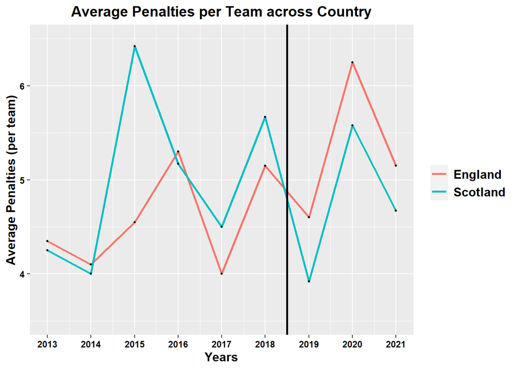

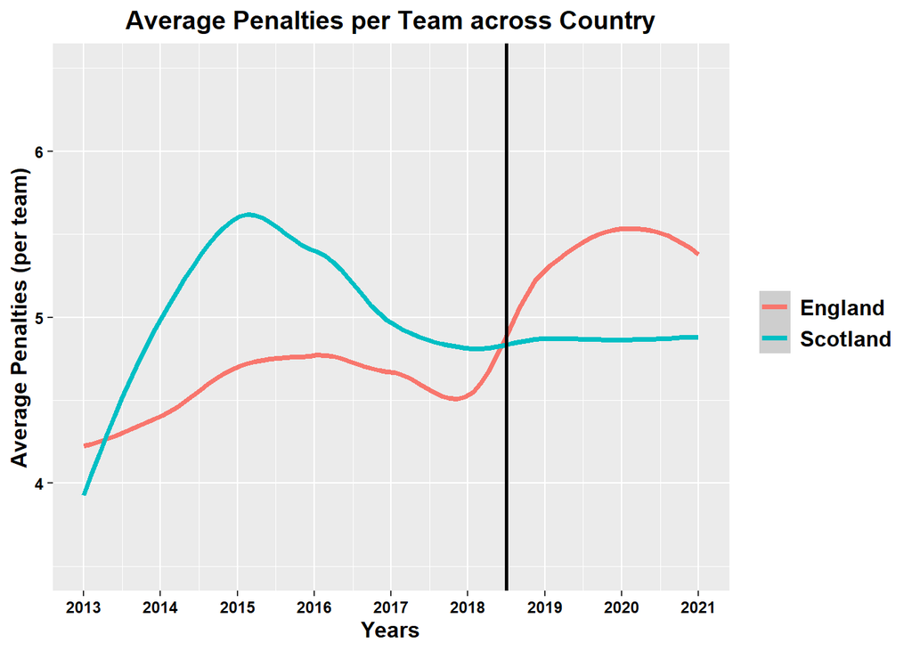

The fourth graph shows the exact thing we are looking to find more information about. With the smoothed lines a more clear pattern emerges. With the penalties in Scotland showing a little more of an upward trend in the pre-period than would initially be suspected with the line of best fit from the second graph. But the overall upward trend that was hypothesized in our motivation section is shown with a bit more impact with the smoothed Scotland line showing a level trend that further warrants our difference and difference study with the policy change in England, as England shows a drastic increase compared to Scotland.

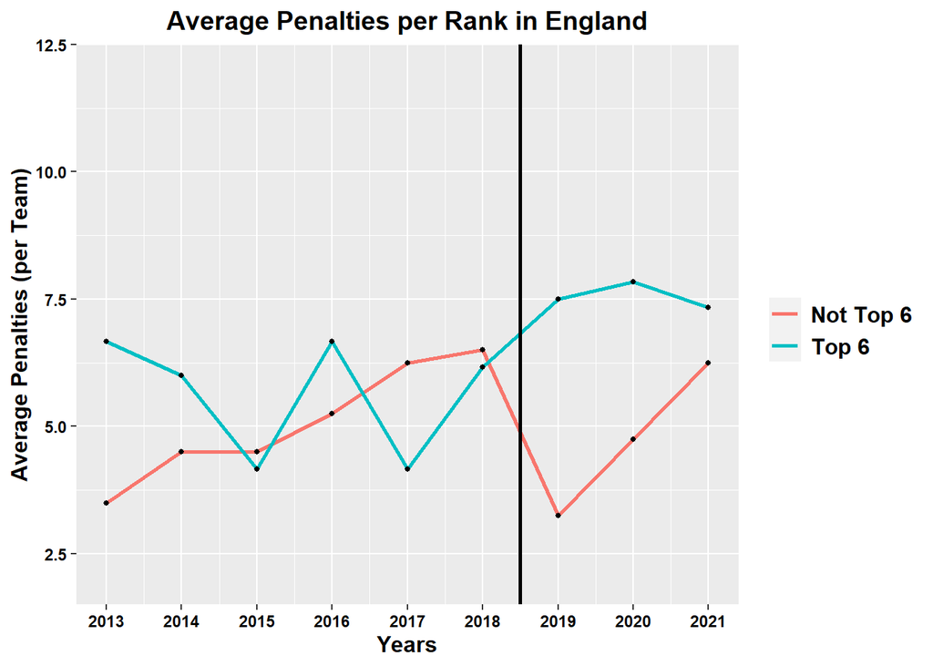

## Econometric Analysis

### Methods

As discussed above, our econometric analysis methodology is a difference-in-difference method. We used the randomness of the policies implementation to understand the relationship between the policy and penalties received. Our research question is a causal one due to having this natural experiment to exploit. There are three models that we ran in order to understand the relationship, all using robust standard errors. The first is the main model of interest, whereas the last two models try to understand the differential impact of the policy on bigger clubs compared to smaller clubs.

#### Reg_1

$$PenaltiesReceived_{ict}= β_0 + β_1 (Post_t * Treat_{ic}) + β_2 Post_t + β_3 Treat_{ic} + ∈_{ict}$$
$PenaltiesReceived_{ct}$ represents penalties received by individual club i in Country c in year t. $β_0$ is the treatment effect at the moment of the VAR addition. $β_1$ is the coefficient of interest, this measures the with-in country difference in penalties received before and after VAR is implemented, conditional on year fixed effects. The interaction term is a dummy variable, 0 when country has no VAR and 1 for having it in place. $β_2$ represents country fixed effects, controlling for factors that are constant within country over-time. $Treat_ic$ is a dummy variable that is 0 for clubs in Scotland and 1 for England. $β_3$ represents time fixed effects, controlling for patterns over time that exist within the United Kingdom. $Post_t$ is also a dummy variable, 0 pre-treatment and 1 post.

#### Reg_2

$$PenaltiesReceived_{ict}= β_0 + β_1 (Post_t * Top6_{ic}) + β_2 Post_t + β_3 Top6_{ic} + ∈_{ict}$$
This model has the same structure of the first model. The difference is that it is comparing differences within the treatment group. We want to know if bigger teams benefit from this policy differently than smaller teams. In order to do this the teams in the English football league are divided into either top 6 or not top 6. These teams are well established as the ‘top 6’ by professionals and the general public due to their performance and financial power. This includes clubs like Manchester United, Liverpool FC, and Arsenal FC. This is of course an arbitrary cut off, however the difference between the 6th and 7th best team is large and the finances within the top 6 teams are comparable, indicating that this is an effective cut off.

This is a form of placebo test where both groups received the treatment, therefore we would expect the interaction term to be zero. If a statistically significant interaction term is found, the policy has differential impacts for big vs small teams. To conduct the test the treatment ($Top6_{ic}$) was classed as being in the top 6. This is not a real difference-in-difference model so coefficients can not be taken literally, however it is a means to show the differential impacts of the policy.

The best way to run this model would be to have a synthetic control where the entire league has a simulated trend from 2018-present in order to capture what the games would look like without the instant replay. From here there would be a diff-diff run to distinguish the difference between the synthetic control league and the treatment league, to capture the aggregate effect. After this a binary variable can be created for teams that are in the top 6 and not in the top 6 in each data set. And the means of each variable of penalties received between each category within the data set can be calculated. From here the means of difference in penalties received from top 6 vs not top 6 from each data set can be compared to see how the policy effected each category.

#### Reg_3

$$PenaltiesReceived_{ict}= β_0 + β_1 (Post_t * TreatTop6_{ic}) + β_2 Post_t + β_3 TreatTop6_{ic} + ∈_{ict}$$
This third model is run to understand the effect of the policy on big teams. Therefore, this model is the same as regression 1, however only uses data from big teams in Scotland and England. A similar process was done to find top teams in Scotland. The teams are well established as the best teams in the country. Through this regression we can isolate whether big teams in England received more penalties as a result of the policy.

##### Ideal Experiment

The ideal experiment for all models would be to have all clubs and all teams have the same budget and then have the same players be randomly assigned to teams that would have instant replay, and teams that would not. The teams would be randomly assigned to have instant replay or not as well. Then have them play the same number of games over a longer period. Then repeating the process once every several years, and then comparing the aggregate differences over time. In order to progress from this stage there would hopefully be more years to draw from the sample, and in addition other countries with similar characteristics in their football leagues. From here more in depth and robust models could be run in order to capture a bigger picture of how this effects football.

### Results

|  | Reg_1 | Reg_2 | Reg_3 |
| --- | --- | --- | --- |
| (Intercept) | 5.00 | 5.08 | 6.61 |
|  | (0.30) | (0.47) | (0.62) |
| Time | −0.28 | −0.33 | −0.68 |
|  | (0.49) | (0.71) | (0.84) |
| Area | −0.39 | 0.56 | −0.97 |
|  | (0.38) | (0.62) | (0.74) |
| Interaction | 1.00 | 2.25 | 2.60 |
|  | (0.66) | (1.06) | (1.15) |
| Num.Obs. | 287 | 90 | 91 |
| R2 | 0.012 | 0.138 | 0.074 |
| R2 Adj. | 0.001 | 0.108 | 0.042 |
| AIC | 1368.9 | 421.3 | 440.1 |
| BIC | 1387.2 | 433.8 | 452.6 |
| RMSE | 2.58 | 2.38 | 2.57 |

#### Problems for Causality

One issue surrounds the randomness of the policy. The fact that this policy was first implemented in England, is not completely random. Firstly, VAR technology is expensive, therefore not all leagues can afford it. Additionally, the English league is the most watched league in the world, therefore there is likely a tie between them implementing the policy first and their footballing stature. Having said that, I found no evidence to suggest that this could affect the number of penalties that are awarded in any given match.

Results may not be generalized to other countries for a few reasons. A countries style of play could have an impact on the effects of VAR. A country with worse players may make more fouls, resulting in more decisions being picked up by VAR and more penalties being given. In this case, effects outside of England would be stronger than what was found in this study. Our coefficient could be an overestimation of the effect in other leagues however if attackers are better in England, forcing defenders into more mistakes. Another difference that could be seen in other leagues is that they may have consistent effects across teams within the league. If a league is more competitive, with less financial disparity the differential effects found may be misleading.

There is a possibility of omitted variables bias existing. If we take ground quality for example, a water logged field may result in more mistakes by defenders, leading to more penalties. In this case, if field quality dropped in the years past the policy in the treatment group, this could overestimate the true effect of the policy. Additionally, generalizing England’s results to countries with worse weather and field quality may lead to an underestimation of the effects in that country.

### Conclusion

What are results show is that VAR has increased the number penalties received by clubs somewhat, however this finding is not statistically significant. We do find statistically significant evidence of differential impacts of the policy between teams. Better, more financially supported teams benefit largely from the policy whereas smaller teams do not. This suggests that the policy has increased the disparity in results for big vs small teams. This may be a bad outcome for the sport as it causes the game to be less competitive with big teams winning more often. One explanation for the differential impacts is that better teams are more likely to be attacking and be in the other teams 18 yard box where penalties can be awarded. Therefore, they are the teams that will see the benefits from video replay.

It is important to understand whether these extra penalties that are given because of VAR are the correct decision. If this is true, then the extra penalties given to bigger teams are warranted and these teams doing better is a closer representation to their true performance level. However, if these extra penalties are soft and only given because the slow-motion replies make the fouls look worse than they really are, then this policy is no fair and bad for the game in general. In other words is the video replay picking up real fouls that would have otherwise been missed without the technology, or is the technology causing excess penalties.

This deeper understanding of whether the policy is a good thing for the sport is beyond the scope of this project. However, what we have shown is that the policy has large impacts on penalties received for bigger teams, and that this may have negative impacts on the competitiveness of the sport. We hope this inspires further research into the wide spread impacts this policy has on the sport.